# Dados Sobre Séries de TV - Checkpoin 1

Antunes Dantas

Atividade proposta na disciplina Análise de Dados I da Universidade Federal de Campina Grande, este estudo propõe analisar dados de séries de TV obtidos do IMDb, um banco de dados online de filmes e séries.

```r
# Instalando os pacotes necessarios
#install.packages(c("dplyr", "tidyr", "ggplot2", "readr"))
library("ggplot2")
library("dplyr")
library("tidyr")
library("readr")
```

```r
# Importando o arquivo com os dados
setwd('/local_home/epol-antunes/Documentos/analise_de_dados1')
series <- read.csv('series_from_imdb.csv')
```

O banco de dados utilizado contém 31 séries, escolhidas aleatoriamente:

```r
# Mostrando as séries disponíveis
unique(series$series_name) %>%
  sort()
```

```
##  [1] 13 Reasons Why              Agents of S.H.I.E.L.D.
##  [3] Arrow                       Black Mirror
##  [5] Breaking Bad                Daredevil
##  [7] Dexter                      Flash
##  [9] Friends                     Game of Thrones
## [11] Gotham                      Grey’s Anatomy
## [13] Homeland                    House of Cards
## [15] How I Met Your Mother       How to Get Away with Murder
## [17] Modern Family               Mr Robot
## [19] Narcos                      Once Upon a Time
## [21] Orphan Black                Prison Break
## [23] Scandal                     Sense8
## [25] Sherlock                    Stranger Things
## [27] The 100                     The Blacklist
## [29] The Simpsons                The Walking Dead
## [31] Vikings
## 31 Levels: 13 Reasons Why Agents of S.H.I.E.L.D. Arrow ... Vikings
```

Dentre essas séries, escolhi quatro para analisar: Friends, How I Met Your Mother, Modern Family e The Simpons. Escolhi essas por terem um formato semelhante: comédia com vinte minutos de duração.

```r
# Criando um novo conjunto de dados apenas com as séries em estudo
series_analisadas <- series %>%
  filter(series_name %in% c("Friends", "Modern Family", "The Simpsons", "How I Met Your Mother"))
```

Como falado anteriormente, o conjunto de dados foi baixado do IMDb. Então, temos disponível as seguintes informações de cada série:

```r
names(series_analisadas)
```

```
##  [1] "series_name" "series_ep"   "season"      "season_ep"   "url"
##  [6] "Episode"     "UserRating"  "UserVotes"   "r1"          "r10"
## [11] "r2"          "r3"          "r4"          "r5"          "r6"
## [16] "r7"          "r8"          "r9"
```

Como mostrado acima, temos disponível todos os episódios lançados até a data de publicação desse estudo (20 de Maio de 2017) das séries, também uma média da nota dada pelos usuários do IMDb para cada episódio. Com isso, podemos responder a algumas perguntas como: Qual a série mais bem avaliada pelos usuários? A diferença é grande? Pequena? Qual das séries tem episódios de qualidade mais irregular segundo o IMDB? A diferença é grande? Pequena?

Para tentar responder a primeira pergunta, vamos montar um gráfico de pontos, onde cada ponto representa a nota de um episódio. Neste primeiro momento, não vamos separar os dados por temporada, apenas por série. No eixo x, o nome da série. No y, as notas dos usuários.

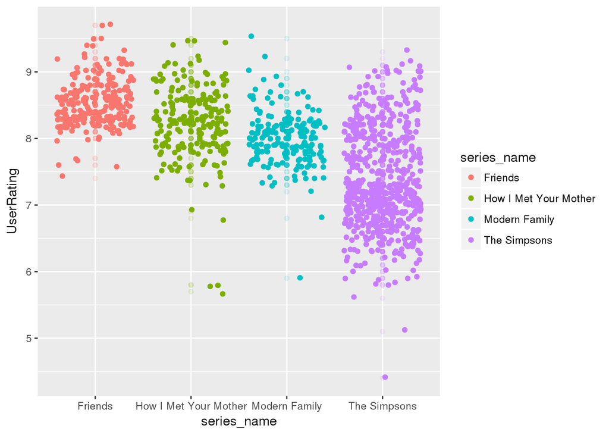

```r
grafico_series <- ggplot(series_analisadas, aes(x = series_name, y = UserRating, color = series_name)) +
  geom_point(alpha = 0.1) +
  geom_jitter()

grafico_series
```

Como pode ser visto, Friends possui uma grande quantidade de pontos distribuídos próximos uns aos outros. No lado oposto, The Simpons possui pontos distribuídos em várias faixas, indicando uma variedade na qualidade de cada episódio. O gráfico de caixa a seguir ajudará a ter uma ideia mais clara da distribuição dos pontos:

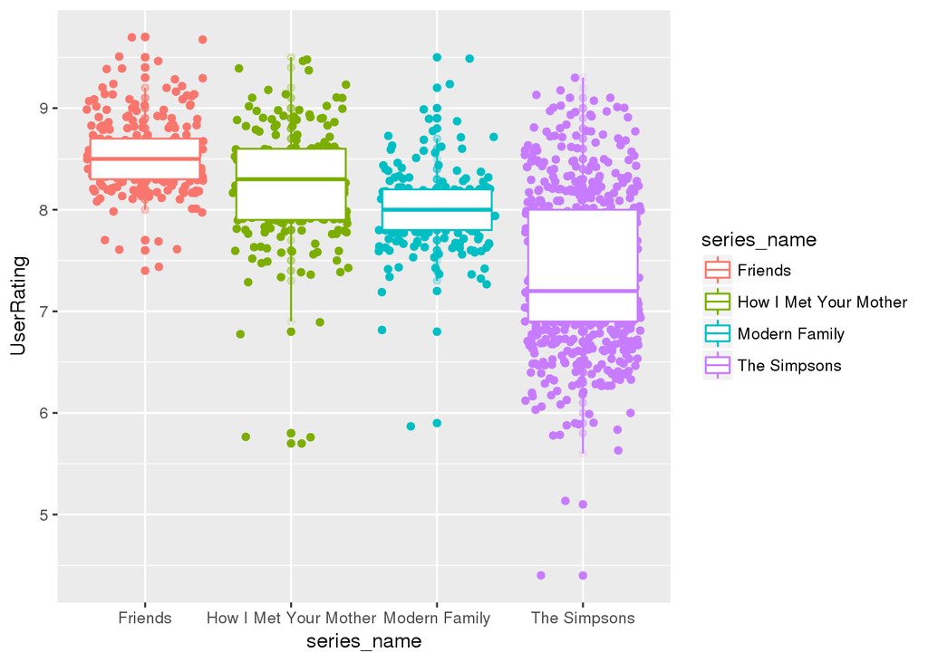

```r
grafico_series +
  geom_boxplot()
```

Com estes gráficos, é seguro afirmar que Friends é a série mais bem avaliada. A nota mais alta é de um episódio dessa série, seus pontos tem uma distribuição muito próxima (grande parte dos episódios com nota entre oito e nove), a mediana também é a mais alta. Outro dado estatístico que podemos usar é a média. Novamente, Friends se mostra a série mais bem avaliada.

```r
group_by(series_analisadas, series_name) %>%
  summarise(mean = mean(UserRating))
```

```
## # A tibble: 4 x 2
##             series_name     mean
##                  <fctr>    <dbl>
## 1               Friends 8.541102
## 2 How I Met Your Mother 8.229327
## 3         Modern Family 7.989305
## 4          The Simpsons 7.366721
```

Para avaliar a regularidade na nota dos episódios, utilizarei outro artifício da estatística: o desvio padrão. Quanto maior o desvio padrão, maior será a irregularidade na nota dos usuários.

```r
group_by(series_analisadas, series_name) %>%
  summarise(desvio_padrao = sd(UserRating))
```

```
## # A tibble: 4 x 2
##             series_name desvio_padrao
##                  <fctr>         <dbl>
## 1               Friends     0.3579570
## 2 How I Met Your Mother     0.5597235
## 3         Modern Family     0.4028034
## 4          The Simpsons     0.7418366
```

```r
group_by(series_analisadas, series_name) %>%
  summarise(mais_baixo = min(UserRating), mais_alto = max(UserRating))
```

```
## # A tibble: 4 x 3
##             series_name mais_baixo mais_alto
##                  <fctr>      <dbl>     <dbl>
## 1               Friends        7.4       9.7
## 2 How I Met Your Mother        5.7       9.5
## 3         Modern Family        5.9       9.5
## 4          The Simpsons        4.4       9.3
```